# BEDASSLE results

We used SLURM to run bedassle for all species in parallel. Now we will load the results and work with the inferences.

In particular, we will evaluate the runs to check if they converged. Then we will make IBD plots for all species, including model predictions. Finally we will obtain the posterior distribution of $\alpha_{diff} = \alpha_p - \alpha_g$, which shows, across species, the relative importance of geography and host plant.

Finally, we will run a hierarchical model in STAN to test if the distribution of $\alpha_{diff}$can be explained by variation in species interactions. We will also test the power of this test by relabeling species to check if we could detect this with our sample sizes.

```r
dyn.load('~/labdir/working/inaturalist_flowers/v8/lib/libv8.so')
rm(list=ls())
library(rstan)
library(rstantools)
library(tidyverse)
library(broom)
library(ggthemes)
library(cowplot)
library(colorspace)
library(ggnewscale)
```

# Load HMC results

We will first run one example for **Anchylorhynchus trapezicollis** OTU 1 and then apply the same procedures as a function to all species.

Let's load the rstan model for **Anchylorhynchus trapezicollis** OTU 1:

```r
species = 'Anchylorhynchus_1'
load(str_c('bedassle_results/',species,'_model.fit.Robj'))
```

Each model can be diagnosed interactively with `shinystan::launch_shinystan(model.fit)`. We will do that below for all species, and for now will proceed to summarizing the posterior distributions by their mean and 95% credibility interval.

```r
estimates = summary(model.fit, pars=c('alphaE','alphaD','alpha2'))$summary %>%
  as.data.frame() %>%
  rownames_to_column('parameter') %>%
  dplyr::select(parameter,mean,`2.5%`,`97.5%`) %>%
  mutate_at(vars(-parameter),sprintf,fmt='%0.4f') %>%
  mutate(posterior=str_c(mean,' (',`2.5%`,'--',`97.5%`,')')) %>%
  select(parameter, posterior)
estimates
```

| parameter | posterior |
| --- | --- |
| alphaE[1] | 0.1614 (0.1566--0.1664) |
| alphaD | 0.0196 (0.0174--0.0217) |
| alpha2 | 1.7558 (1.7316--1.7799) |

Now let's change parameter names to reflect to which distance they refer to. We will start by making a named vector to translate names

```r
translation = c('alpha2'='$\alpha_2$',
                'alphaD'='$\alpha_{geo}$',
                'alphaE[1]' = '$\alpha_{plant}$')
```

Now it is easy to use this vector.

```r
estimates = estimates %>%
  mutate(parameter = translation[parameter])
```

Now that we know how this works, let's do it for all species. We will also format numbers as scientific notation.

```r
get_posteriors = function(species){

  load(str_c('bedassle_results/',species,'_model.fit.Robj'))



  estimates = summary(model.fit,
                      pars=intersect(c('alphaE[1]',
                                       'alphaE[2]',
                                       'alpha0',
                                       'alphaD',
                                       'alpha2'),
                                     names(model.fit))) %>%
    .[['summary']] %>%
    as.data.frame() %>%
    rownames_to_column('parameter') %>%
    dplyr::select(parameter,mean,`2.5%`,`97.5%`) %>%
    mutate(mean = ifelse(parameter %in% c('alpha0', 'alpha2'),
                         sprintf(mean, fmt='%0.2f'),
                         sprintf(mean, fmt='%0.2e')),
           `2.5%` = ifelse(parameter %in% c('alpha0', 'alpha2'),
                         sprintf(`2.5%`, fmt='%0.2f'),
                         sprintf(`2.5%`, fmt='%0.2e')),
           `97.5%` = ifelse(parameter %in% c('alpha0', 'alpha2'),
                         sprintf(`97.5%`, fmt='%0.2f'),
                         sprintf(`97.5%`, fmt='%0.2e')),
           ) %>%
    mutate(posterior=str_c(mean,' (',`2.5%`,'--',`97.5%`,')')) %>%
    dplyr::select(parameter, posterior)

  translation = c('alpha2'='$\\alpha_2$',
                  'alpha0'='$\\alpha_0$',
                  'gamma'='$\\gamma$',
                  'alphaD'='$\\alpha_{geo}$',
                  'alphaE[1]' = '$\\alpha_{plant}$')

  return(estimates %>%
           mutate(parameter = translation[parameter]))
}
```

Now let's use `purrr` to run this for all species. Let's first create a vector with all species

```r
spp = list.files(path='bedassle_results/',pattern='.*_data.*') %>%
  str_remove('_data.*')
names(spp) = spp
spp
```

```
  Anchylorhynchus_1   Anchylorhynchus_2   Anchylorhynchus_3     Andranthobius_1     Andranthobius_2
"Anchylorhynchus_1" "Anchylorhynchus_2" "Anchylorhynchus_3"   "Andranthobius_1"   "Andranthobius_2"
        C_decolor_1         C_decolor_2             C_impar         D_polyphaga         M_bondari_1
      "C_decolor_1"       "C_decolor_2"           "C_impar"       "D_polyphaga"       "M_bondari_1"
          M_ypsilon          P_cocoseae      R_rectinasus_1
        "M_ypsilon"        "P_cocoseae"    "R_rectinasus_1"
```

Before getting the estimates, let's make sure that the HMC ran well, using shinystan to diagnose the runs. The interactive shinystan page will open in a separate window.

```r
#for (sp in spp){
#  rm(model.fit)
#  load(str_c('bedassle_results/',sp,'_model.fit.Robj'))
#  shinystan::launch_shinystan(model.fit)
#}
```

We can also summarize divergences and other problems for each run:

```r
for (sp in spp){
  cat('=========================\n')
  cat(sp)
  cat('\n')
  rm(model.fit)
  load(str_c('bedassle_results/',sp,'_model.fit.Robj'))
  rstan::check_hmc_diagnostics(model.fit)
  rm(model.fit)
}
```

```
=========================
Anchylorhynchus_1

Divergences:
```

```
0 of 1000 iterations ended with a divergence.
```

```
Tree depth:
```

```
0 of 1000 iterations saturated the maximum tree depth of 10.
```

```
Energy:
```

```
E-BFMI indicated no pathological behavior.
```

```
=========================
Anchylorhynchus_2
```

```
object 'model.fit' not found
```

```
Divergences:
```

```
0 of 1000 iterations ended with a divergence.
```

```
Tree depth:
```

```
0 of 1000 iterations saturated the maximum tree depth of 10.
```

```
Energy:
```

```
E-BFMI indicated no pathological behavior.
```

```
=========================
Anchylorhynchus_3
```

```
object 'model.fit' not found
```

```
Divergences:
```

```
0 of 1000 iterations ended with a divergence.
```

```
Tree depth:
```

```
0 of 1000 iterations saturated the maximum tree depth of 10.
```

```
Energy:
```

```
E-BFMI indicated no pathological behavior.
```

```
=========================
Andranthobius_1
```

```
object 'model.fit' not found
```

```
Divergences:
```

```
0 of 1000 iterations ended with a divergence.
```

```
Tree depth:
```

```
0 of 1000 iterations saturated the maximum tree depth of 10.
```

```
Energy:
```

```
E-BFMI indicated no pathological behavior.
```

```
=========================
Andranthobius_2
```

```
object 'model.fit' not found
```

```
Divergences:
```

```
0 of 1000 iterations ended with a divergence.
```

```
Tree depth:
```

```
0 of 1000 iterations saturated the maximum tree depth of 10.
```

```
Energy:
```

```
E-BFMI indicated no pathological behavior.
```

```
=========================
C_decolor_1
```

```
object 'model.fit' not found
```

```
Divergences:
```

```
0 of 1000 iterations ended with a divergence.
```

```
Tree depth:
```

```
0 of 1000 iterations saturated the maximum tree depth of 10.
```

```
Energy:
```

```
E-BFMI indicated no pathological behavior.
```

```
=========================
C_decolor_2
```

```
object 'model.fit' not found
```

```
Divergences:
```

```
0 of 1000 iterations ended with a divergence.
```

```
Tree depth:
```

```
0 of 1000 iterations saturated the maximum tree depth of 10.
```

```
Energy:
```

```
E-BFMI indicated no pathological behavior.
```

```
=========================
C_impar
```

```
object 'model.fit' not found
```

```
Divergences:
```

```
0 of 1000 iterations ended with a divergence.
```

```
Tree depth:
```

```
0 of 1000 iterations saturated the maximum tree depth of 10.
```

```
Energy:
```

```
E-BFMI indicated no pathological behavior.
```

```
=========================
D_polyphaga
```

```
object 'model.fit' not found
```

```
Divergences:
```

```
0 of 1000 iterations ended with a divergence.
```

```
Tree depth:
```

```
0 of 1000 iterations saturated the maximum tree depth of 10.
```

```
Energy:
```

```
E-BFMI indicated no pathological behavior.
```

```
=========================
M_bondari_1
```

```
object 'model.fit' not found
```

```
Divergences:
```

```
0 of 1000 iterations ended with a divergence.
```

```
Tree depth:
```

```
0 of 1000 iterations saturated the maximum tree depth of 10.
```

```
Energy:
```

```
E-BFMI indicated no pathological behavior.
```

```
=========================
M_ypsilon
```

```
object 'model.fit' not found
```

```
Divergences:
```

```
0 of 1000 iterations ended with a divergence.
```

```
Tree depth:
```

```
0 of 1000 iterations saturated the maximum tree depth of 10.
```

```
Energy:
```

```
E-BFMI indicated no pathological behavior.
```

```
=========================
P_cocoseae
```

```
object 'model.fit' not found
```

```
Divergences:
```

```
0 of 1000 iterations ended with a divergence.
```

```
Tree depth:
```

```
0 of 1000 iterations saturated the maximum tree depth of 10.
```

```
Energy:
```

```
E-BFMI indicated no pathological behavior.
```

```
=========================
R_rectinasus_1
```

```
object 'model.fit' not found
```

```
Divergences:
```

```
0 of 1000 iterations ended with a divergence.
```

```
Tree depth:
```

```
0 of 1000 iterations saturated the maximum tree depth of 10.
```

```
Energy:
```

```
E-BFMI indicated no pathological behavior.
```

Now let's get a dataframe with estimates for all species:

```r
all_spp_par = purrr::map_df(spp,get_posteriors,.id = 'species')
all_spp_par
```

| species | parameter | posterior |
| --- | --- | --- |
| Anchylorhynchus_1 | $\\alpha_{plant}$ | 1.61e-01 (1.57e-01--1.66e-01) |
| Anchylorhynchus_1 | $\\alpha_0$ | 0.23 (0.22--0.23) |
| Anchylorhynchus_1 | $\\alpha_{geo}$ | 1.96e-02 (1.74e-02--2.17e-02) |
| Anchylorhynchus_1 | $\\alpha_2$ | 1.76 (1.73--1.78) |
| Anchylorhynchus_2 | $\\alpha_{plant}$ | 1.95e-04 (5.98e-06--5.36e-04) |
| Anchylorhynchus_2 | $\\alpha_0$ | 0.20 (0.19--0.20) |
| Anchylorhynchus_2 | $\\alpha_{geo}$ | 5.25e-02 (4.93e-02--5.54e-02) |
| Anchylorhynchus_2 | $\\alpha_2$ | 1.03 (1.01--1.05) |
| Anchylorhynchus_3 | $\\alpha_{plant}$ | 1.58e-01 (4.46e-02--2.43e-01) |
| Anchylorhynchus_3 | $\\alpha_0$ | 0.06 (0.06--0.07) |

[output cut: 42 more lines]

# Make supplementary table

Finally, we just need to reshape the data frame to put it in the paper. Let's save it as a csv file for further editing.

```r
bedassle_table = all_spp_par %>%
  spread(key=parameter,value=posterior)
bedassle_table
```

| species | $\alpha_0$ | $\alpha_2$ | $\alpha_{geo}$ | $\alpha_{plant}$ |
| --- | --- | --- | --- | --- |
| Anchylorhynchus_1 | 0.23 (0.22--0.23) | 1.76 (1.73--1.78) | 1.96e-02 (1.74e-02--2.17e-02) | 1.61e-01 (1.57e-01--1.66e-01) |
| Anchylorhynchus_2 | 0.20 (0.19--0.20) | 1.03 (1.01--1.05) | 5.25e-02 (4.93e-02--5.54e-02) | 1.95e-04 (5.98e-06--5.36e-04) |
| Anchylorhynchus_3 | 0.06 (0.06--0.07) | 1.04 (0.36--1.87) | 1.62e-01 (4.29e-02--2.49e-01) | 1.58e-01 (4.46e-02--2.43e-01) |
| Andranthobius_1 | 0.22 (0.22--0.23) | 0.74 (0.64--0.85) | 9.16e-05 (2.21e-05--2.37e-04) | 1.50e-06 (2.91e-08--6.54e-06) |
| Andranthobius_2 | 0.18 (0.18--0.19) | 1.20 (0.72--1.80) | 7.83e-04 (2.21e-05--2.94e-03) | 1.14e-02 (8.67e-04--3.33e-02) |
| C_decolor_1 | 0.20 (0.19--0.20) | 1.13 (1.09--1.17) | 7.01e-02 (6.46e-02--7.57e-02) | 3.62e-04 (1.14e-05--1.04e-03) |
| C_decolor_2 | 0.14 (0.13--0.15) | 1.93 (1.76--2.00) | 2.14e-01 (2.01e-01--2.26e-01) | 1.28e-02 (5.96e-04--3.49e-02) |
| C_impar | 0.22 (0.21--0.23) | 0.66 (0.64--0.67) | 6.64e-03 (5.90e-03--7.47e-03) | 2.54e-04 (1.91e-04--3.18e-04) |
| D_polyphaga | 0.20 (0.19--0.21) | 0.43 (0.38--0.50) | 9.20e-03 (4.83e-03--1.54e-02) | 4.19e-05 (1.36e-06--1.42e-04) |
| M_bondari_1 | 0.20 (0.19--0.21) | 1.90 (1.69--2.00) | 5.52e-02 (4.41e-02--6.20e-02) | 3.85e-02 (2.88e-02--4.40e-02) |

[output cut: 3 more lines]

```r
write_csv(bedassle_table,'bedassle_results/final_table.csv')
```

# Make IBD figure

To do that, we will load the data used in bedassle (pairwise pi and distances). Let's start with allele frequencies to obtain sample genetic covariances.

```r
add_dimnames = function(x, x_names){
  dimnames(x) = x_names
  return(x)
}
load(file = 'weevils_freq_data.Rdata')
ppi1 = purrr::map_df(BEDASSLE_data,~bedassle::freqs2pairwisePi(.x$freqs/2) %>%
                           add_dimnames(dimnames(.x$freqs)) %>%
                           as.dist %>%
                           broom::tidy(diagonal=F, upper=F),
                           .id = 'species') %>%
  rename(sample1 = item1,
         sample2 = item2,
         pi = distance)
```

[output not shown]

[output cut: 1814 more lines]

[output not shown]

```r
ppi1
```

| species | sample1 | sample2 | pi |
| --- | --- | --- | --- |
| Anchylorhynchus_1 | BdM1012 | BdM1013 | 0.03805042 |
| Anchylorhynchus_1 | BdM1012 | BdM1014 | 0.03526200 |
| Anchylorhynchus_1 | BdM1012 | BdM1015 | 0.03607529 |
| Anchylorhynchus_1 | BdM1012 | BdM1016 | 0.03613338 |
| Anchylorhynchus_1 | BdM1012 | BdM1017 | 0.03642384 |
| Anchylorhynchus_1 | BdM1012 | BdM1018 | 0.03375160 |
| Anchylorhynchus_1 | BdM1012 | BdM1019 | 0.04217497 |
| Anchylorhynchus_1 | BdM1012 | BdM1031 | 0.06279772 |
| Anchylorhynchus_1 | BdM1012 | BdM1034 | 0.06576043 |
| Anchylorhynchus_1 | BdM1012 | BdM1035 | 0.07557802 |

[output cut: 990 more lines]

Now let's load data on the other distances and combine in this table.

```r
pops = readr::read_csv('weevil_data.csv',guess_max = 1000) %>%
  select(genomics, population = pop_id_thesis) %>%
  distinct
ppi = ppi1 %>%
  left_join(pops, by = c('sample1'='genomics')) %>%
  rename(pop1 = population) %>%
  left_join(pops, by = c('sample2'='genomics')) %>%
  rename(pop2 = population)
load(file = 'plant_distances.Rdata')
load(file = 'worldclim/distances.Rdata')
ppi =  ppi %>%
  left_join(geo_dist %>%
              as.dist() %>%
              broom::tidy(diagonal=T, upper=F),
            by = c('pop1'='item1',
                   'pop2'='item2')) %>%
  rename(geo_dist=distance)
ppi =  ppi %>%
  left_join(plant_dist %>%
              as.dist() %>%
              broom::tidy(diagonal=T, upper=F),
            by = c('pop1'='item1',
                   'pop2'='item2')) %>%
  rename(plant_dist=distance)
ppi
```

| species | sample1 | sample2 | pi | pop1 | pop2 | geo_dist | plant_dist |
| --- | --- | --- | --- | --- | --- | --- | --- |
| Anchylorhynchus_1 | BdM1012 | BdM1013 | 0.03805042 | P2 | P2 | 0.00000 | 0.000000000 |
| Anchylorhynchus_1 | BdM1012 | BdM1014 | 0.03526200 | P2 | P2 | 0.00000 | 0.000000000 |
| Anchylorhynchus_1 | BdM1012 | BdM1015 | 0.03607529 | P2 | P2 | 0.00000 | 0.000000000 |
| Anchylorhynchus_1 | BdM1012 | BdM1016 | 0.03613338 | P2 | P2 | 0.00000 | 0.000000000 |
| Anchylorhynchus_1 | BdM1012 | BdM1017 | 0.03642384 | P2 | P2 | 0.00000 | 0.000000000 |
| Anchylorhynchus_1 | BdM1012 | BdM1018 | 0.03375160 | P2 | P2 | 0.00000 | 0.000000000 |
| Anchylorhynchus_1 | BdM1012 | BdM1019 | 0.04217497 | P2 | P2 | 0.00000 | 0.000000000 |
| Anchylorhynchus_1 | BdM1012 | BdM1031 | 0.06279772 | P2 | P5 | 410.42959 | 0.005140179 |
| Anchylorhynchus_1 | BdM1012 | BdM1034 | 0.06576043 | P2 | P6 | 510.41580 | 0.005310939 |
| Anchylorhynchus_1 | BdM1012 | BdM1035 | 0.07557802 | P2 | P6 | 510.41580 | 0.005310939 |

[output cut: 990 more lines]

Now let's reshape the table to use ggplot2 for plotting.

```r
ppi = ppi %>%
  gather(key='variable',value='distance',ends_with('dist')) %>%
  filter(!is.na(distance))
ppi
```

| species | sample1 | sample2 | pi | pop1 | pop2 | variable | distance |
| --- | --- | --- | --- | --- | --- | --- | --- |
| Anchylorhynchus_1 | BdM1012 | BdM1013 | 0.03805042 | P2 | P2 | geo_dist | 0.000000 |
| Anchylorhynchus_1 | BdM1012 | BdM1014 | 0.03526200 | P2 | P2 | geo_dist | 0.000000 |
| Anchylorhynchus_1 | BdM1012 | BdM1015 | 0.03607529 | P2 | P2 | geo_dist | 0.000000 |
| Anchylorhynchus_1 | BdM1012 | BdM1016 | 0.03613338 | P2 | P2 | geo_dist | 0.000000 |
| Anchylorhynchus_1 | BdM1012 | BdM1017 | 0.03642384 | P2 | P2 | geo_dist | 0.000000 |
| Anchylorhynchus_1 | BdM1012 | BdM1018 | 0.03375160 | P2 | P2 | geo_dist | 0.000000 |
| Anchylorhynchus_1 | BdM1012 | BdM1019 | 0.04217497 | P2 | P2 | geo_dist | 0.000000 |
| Anchylorhynchus_1 | BdM1012 | BdM1031 | 0.06279772 | P2 | P5 | geo_dist | 410.429589 |
| Anchylorhynchus_1 | BdM1012 | BdM1034 | 0.06576043 | P2 | P6 | geo_dist | 510.415797 |
| Anchylorhynchus_1 | BdM1012 | BdM1035 | 0.07557802 | P2 | P6 | geo_dist | 510.415797 |

[output cut: 990 more lines]

Before plotting, let's add information about insect-plant interactions

```r
ecology = data.frame(species = spp,
                     interaction= c(rep('Brood pollinator',3),
                                    rep('Dead tissue breeder', 6),
                                    rep('Live tissue breeder', 2),
                                    'Dead tissue breeder',
                                    'Live tissue breeder'
                                    ))
ppi = ppi %>%
  left_join(ecology)
ppi
```

| species | sample1 | sample2 | pi | pop1 | pop2 | variable | distance | interaction |
| --- | --- | --- | --- | --- | --- | --- | --- | --- |
| Anchylorhynchus_1 | BdM1012 | BdM1013 | 0.03805042 | P2 | P2 | geo_dist | 0.000000 | Brood pollinator |
| Anchylorhynchus_1 | BdM1012 | BdM1014 | 0.03526200 | P2 | P2 | geo_dist | 0.000000 | Brood pollinator |
| Anchylorhynchus_1 | BdM1012 | BdM1015 | 0.03607529 | P2 | P2 | geo_dist | 0.000000 | Brood pollinator |
| Anchylorhynchus_1 | BdM1012 | BdM1016 | 0.03613338 | P2 | P2 | geo_dist | 0.000000 | Brood pollinator |
| Anchylorhynchus_1 | BdM1012 | BdM1017 | 0.03642384 | P2 | P2 | geo_dist | 0.000000 | Brood pollinator |
| Anchylorhynchus_1 | BdM1012 | BdM1018 | 0.03375160 | P2 | P2 | geo_dist | 0.000000 | Brood pollinator |
| Anchylorhynchus_1 | BdM1012 | BdM1019 | 0.04217497 | P2 | P2 | geo_dist | 0.000000 | Brood pollinator |
| Anchylorhynchus_1 | BdM1012 | BdM1031 | 0.06279772 | P2 | P5 | geo_dist | 410.429589 | Brood pollinator |
| Anchylorhynchus_1 | BdM1012 | BdM1034 | 0.06576043 | P2 | P6 | geo_dist | 510.415797 | Brood pollinator |
| Anchylorhynchus_1 | BdM1012 | BdM1035 | 0.07557802 | P2 | P6 | geo_dist | 510.415797 | Brood pollinator |

[output cut: 990 more lines]

Before plotting, let's order factors so that plot panels are in the order we want them. Unfortunately, I found no way to make facet labels in ggplot that have only some part in italic and have a line break at the same time. The solution here will be to make everything italic and then manually correct in Adobe Illustrator.

```r
ppi = ppi %>%
  mutate(variable = factor(variable,
                           ordered=T,
                           levels=c('geo_dist','plant_dist'))) %>%
  mutate(interaction = factor(interaction,
                              ordered=T,
                              levels=c('Brood pollinator',
                                       'Live tissue breeder',
                                       'Dead tissue breeder'))) %>%
  mutate(species = factor(species,
                          ordered = T,
                          levels = c(
                     'Anchylorhynchus_1'  ,
                     'Anchylorhynchus_2'  ,
                     'Anchylorhynchus_3'  ,
                     'M_bondari_1'        ,
                     'M_bondari_2'        ,
                     'M_ypsilon'          ,
                     'R_rectinasus_1'     ,
                     'Andranthobius_1'    ,
                     'Andranthobius_2'    ,
                     'C_decolor_1'        ,
                     'C_decolor_2'        ,
                     'C_impar'            ,
                     'D_polyphaga'        ,
                     'P_cocoseae'
                     ),
                     labels = c(
                     "Anchylorhynchus\ntrapezicollis OTU 1" ,
                     "Anchylorhynchus\ntrapezicollis OTU 2",
                     "Anchylorhynchus\ntrapezicollis OTU 3" ,
                     "Microstrates\nbondari OTU 1"         ,
                     "Microstrates\nbondari OTU 2"         ,
                     "Microstrates\nypsilon"               ,
                     "Remertus\nrectinasus"            ,
                     "Andranthobius\nbondari OTU 1"       ,
                     "Andranthobius\nbondari OTU 2"       ,
                     "Celetes\ndecolor OTU 1"         ,
                     "Celetes\ndecolor OTU 2"         ,
                     "Celetes\nimpar"                 ,
                     "Dialomia\npolyphaga"             ,
                     "Phytotribus\ncocoseae"
                     )
                     )
  )
```

Now that we have the data in the format we need, let's plot.

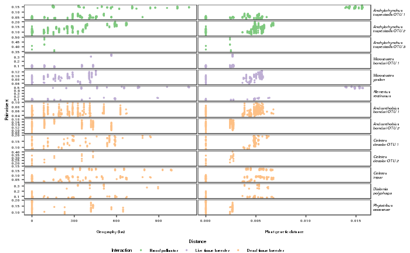

```r
var_labels = c('geo_dist' = 'Geography (km)',
               'plant_dist' = 'Plant genetic distance')
p = ggplot(ppi) +
  geom_point(aes(x=distance, y=pi, color=interaction),size=0.5) +
  #scale_color_manual(values = c('Brood pollinator' = '#47DD8E',
  #                     'Live tissue breeder' = '#DD4756',
  #                     'Dead tissue breeder' = '#DD9C47'), name='Interaction') +
  scale_color_brewer(type='qual', name = 'Interaction') +
  scale_y_continuous(breaks = scales::pretty_breaks(n = 4)) +
  facet_grid(species~variable,
             margins=F,
             scales = 'free',
             labeller = labeller(variable=var_labels, label_value),
             switch='x') +
  xlab('Distance') +
  ylab(expression(Pairwise~pi)) +
  theme_few() +
  theme(strip.text.y = element_text(angle = 0,
                                    hjust = 0,
                                    face = 'italic',
                                    margin = margin(l = 0)),
        strip.placement = "outside",
        legend.position = 'bottom',
        text = element_text(size=6),
        panel.spacing.y = unit(0.1, "lines"),
        panel.spacing.x = unit(0.1, "lines"),
        legend.margin=margin(0,0,0,0),
        legend.box.margin=margin(-13,-12,-11,-12))
print(p)
ggsave(filename = './figures/gen_cov.pdf',
       plot = p,
       device = 'pdf',
       width = 11.4,
       height=12,
       units = 'cm')
```

```r
NA
```

To complete the plot, we will now add the average marginal effect of each distance as inferred by BEDASSLE.

The first step is to tabulate estimated parameters for each species.

```r
get_average_estimates = function(species){

  load(str_c('bedassle_results/',species,'_model.fit.Robj'))
  load(str_c('bedassle_results/',species,'_data.block.Robj'))



  estimates = summary(model.fit,
                      pars=intersect(c('gamma',
                                       'alpha0',
                                       'alphaE[1]',
                                       'alphaE[2]',
                                       'alphaD',
                                       'alpha2'),
                                     names(model.fit))) %>%
    .[['summary']] %>%
    as.data.frame() %>%
    rownames_to_column('parameter') %>%
    dplyr::select(parameter,mean)
  translation = c('gamma' = 'gamma',
                  'alpha2'='alpha_2',
                  'alphaD'='alpha_g',
                  'alpha0'='alpha_0',
                  'alphaE[1]' = 'alpha_p')
  norms = list('norm_g' = data.block$sd.geoDist,
               'norm_p' = data.block$sd.envDist[[1]])

  estimates = estimates %>%
           mutate(parameter = translation[parameter]) %>%
    bind_rows(as.data.frame(norms) %>%
                gather(key = 'parameter',
                       value = 'mean'))

  return(estimates)


}
bedassle_averages = purrr::map_df(spp,get_average_estimates,.id = 'species') %>%
  mutate(parameter = factor(parameter,
                            levels=c("alpha_0",
                                     "alpha_2",
                                     "alpha_g",
                                     "alpha_p",
                                     "norm_g",
                                     "norm_p" )
                            )) %>%
  complete(species,parameter, fill=list(mean = 0))
bedassle_averages
```

| species | parameter | mean |
| --- | --- | --- |
| Anchylorhynchus_1 | alpha_0 | 2.273156e-01 |
| Anchylorhynchus_1 | alpha_2 | 1.755820e+00 |
| Anchylorhynchus_1 | alpha_g | 1.956150e-02 |
| Anchylorhynchus_1 | alpha_p | 1.614226e-01 |
| Anchylorhynchus_1 | norm_g | 2.235902e-01 |
| Anchylorhynchus_1 | norm_p | 3.498851e-01 |
| Anchylorhynchus_2 | alpha_0 | 1.976658e-01 |
| Anchylorhynchus_2 | alpha_2 | 1.029539e+00 |
| Anchylorhynchus_2 | alpha_g | 5.246708e-02 |
| Anchylorhynchus_2 | alpha_p | 1.950878e-04 |

[output cut: 68 more lines]

Let's reshape it to have parameters as columns.

```r
bedassle_averages = bedassle_averages %>%
  spread(parameter,mean)
bedassle_averages
```

| species | alpha_0 | alpha_2 | alpha_g | alpha_p | norm_g | norm_p |
| --- | --- | --- | --- | --- | --- | --- |
| Anchylorhynchus_1 | 0.22731565 | 1.7558198 | 0.0195615050 | 1.614226e-01 | 0.22359016 | 0.34988509 |
| Anchylorhynchus_2 | 0.19766576 | 1.0295394 | 0.0524670842 | 1.950878e-04 | 0.18358203 | 0.10747514 |
| Anchylorhynchus_3 | 0.06022451 | 1.0440987 | 0.1624037149 | 1.583163e-01 | 0.06889598 | 0.06285982 |
| Andranthobius_1 | 0.22371412 | 0.7377745 | 0.0000916442 | 1.497932e-06 | 0.19003221 | 0.09251425 |
| Andranthobius_2 | 0.18406095 | 1.2026595 | 0.0007828305 | 1.137256e-02 | 0.17402499 | 0.06273884 |
| C_decolor_1 | 0.19576434 | 1.1295970 | 0.0701309330 | 3.624304e-04 | 0.21195299 | 0.10854974 |
| C_decolor_2 | 0.13968568 | 1.9308746 | 0.2143636256 | 1.277001e-02 | 0.13450639 | 0.07189130 |
| C_impar | 0.21982057 | 0.6554098 | 0.0066352107 | 2.542680e-04 | 0.18506672 | 0.09573854 |
| D_polyphaga | 0.20307904 | 0.4318408 | 0.0092012285 | 4.186797e-05 | 0.22535073 | 0.10739551 |
| M_bondari_1 | 0.19856657 | 1.8987731 | 0.0552197452 | 3.849852e-02 | 0.15599472 | 0.06588741 |

[output cut: 3 more lines]

Now let's calculate the expected covariance decay for each species and distance. We will use the same formula that bedassle uses internally.

$$Cov=\alpha_0*exp(-(\alpha_d*D)^{\alpha_2})$$

After obtaining genetic covariance, we will calculate pairwise $\pi$. For that, we will use the reverse function that bedassle uses internally:

```r
bedassle::pwp2allelicCov
```

```
function (pi)
{
    check.pi(pi)
    allelic.cov <- (1 - 2 * pi)/4
    return(allelic.cov)
}
<bytecode: 0xfe64618>
<environment: namespace:bedassle>
```

The reverse, therefore, is:
$$\pi=\frac{1}{2}-2*Cov$$

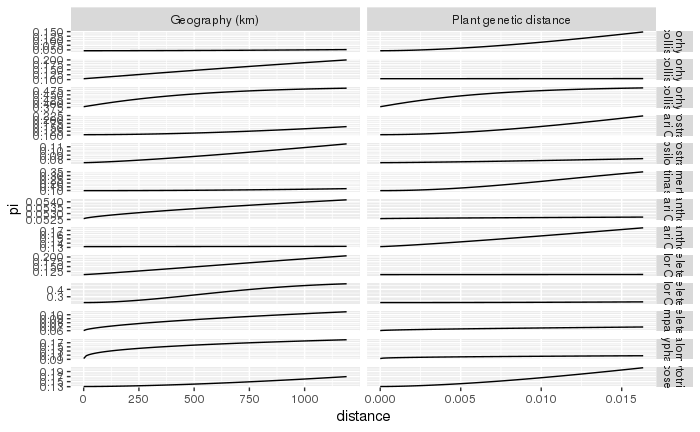

```r
geo_df = split(bedassle_averages, bedassle_averages$species) %>%
  purrr::map_df(~data.frame(
    distance = seq(0,1,length.out = 100) * max(geo_dist),
    covariance = .x$alpha_0 * exp(
    -(seq(0,1,length.out = 100) / .x$norm_g * .x$alpha_g)^.x$alpha_2)
    ),
    .id = 'species') %>%
  mutate(variable = 'geo_dist',
         pi = 1/2 - 2*covariance)
plant_df = split(bedassle_averages, bedassle_averages$species) %>%
  purrr::map_df(~data.frame(
    distance = seq(0,1,length.out = 100) * max(plant_dist),
    covariance= .x$alpha_0 * exp(
    -(seq(0,1,length.out = 100) / .x$norm_p * .x$alpha_p)^.x$alpha_2)
    ),
    .id = 'species') %>%
  mutate(variable = 'plant_dist',
         pi = 1/2 - 2*covariance)
# clim_df = split(bedassle_averages, bedassle_averages$species) %>%
#   purrr::map_df(~data.frame(
#     distance = seq(0,1,length.out = 100) * max(clim_dist),
#     covariance= .x$alpha_0 * exp(
#     -(seq(0,1,length.out = 100) / .x$norm_c * .x$alpha_c)^.x$alpha_2)
#     ),
#     .id = 'species') %>%
#   mutate(variable = 'clim_dist',
#          pi = 1/2 - 2*covariance)


curves_df = bind_rows(geo_df, plant_df) %>%
  left_join(ecology) %>%
  mutate(variable = factor(variable,
                           ordered=T,
                           levels=c('geo_dist','plant_dist'))) %>%
  mutate(interaction = factor(interaction,
                              ordered=T,
                              levels=c('Brood pollinator',
                                       'Live tissue breeder',
                                       'Dead tissue breeder'))) %>%
  mutate(species = factor(species,
                          ordered = T,
                          levels = c(
                     'Anchylorhynchus_1'  ,
                     'Anchylorhynchus_2'  ,
                     'Anchylorhynchus_3'  ,
                     'M_bondari_1'        ,
                     'M_bondari_2'        ,
                     'M_ypsilon'          ,
                     'R_rectinasus_1'     ,
                     'Andranthobius_1'    ,
                     'Andranthobius_2'    ,
                     'C_decolor_1'        ,
                     'C_decolor_2'        ,
                     'C_impar'            ,
                     'D_polyphaga'        ,
                     'P_cocoseae'
                     ),
                     labels = c(
                     "Anchylorhynchus\ntrapezicollis OTU 1" ,
                     "Anchylorhynchus\ntrapezicollis OTU 2",
                     "Anchylorhynchus\ntrapezicollis OTU 3" ,
                     "Microstrates\nbondari OTU 1"         ,
                     "Microstrates\nbondari OTU 2"         ,
                     "Microstrates\nypsilon"               ,
                     "Remertus\nrectinasus"            ,
                     "Andranthobius\nbondari OTU 1"       ,
                     "Andranthobius\nbondari OTU 2"       ,
                     "Celetes\ndecolor OTU 1"         ,
                     "Celetes\ndecolor OTU 2"         ,
                     "Celetes\nimpar"                 ,
                     "Dialomia\npolyphaga"             ,
                     "Phytotribus\ncocoseae"
                     )
                     )
  )
ggplot(curves_df) +
  geom_line(aes(x=distance,y=pi)) +
  facet_grid(species~variable,
             scales = 'free',
             labeller = labeller(variable=var_labels,
                                 species=label_value))
```

Finally, let's plot the curves together with points:

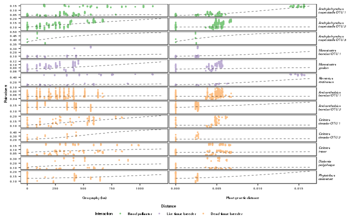

```r
p = ggplot(ppi) +
  geom_point(aes(x=distance, y=pi, color=interaction),size=0.5) +
  geom_line(data = curves_df,
            aes(x=distance,y=pi),size=0.2,linetype='dashed') +
  scale_color_brewer(type='qual', name = 'Interaction') +
  scale_y_continuous(breaks = scales::pretty_breaks(n = 3),
                     labels = function(x) sprintf("%.2f", x)) +
  facet_grid(species~variable,
             margins=F,
             scales = 'free',
             labeller = labeller(variable=var_labels,
                                 species=label_value),
             switch='x') +
  xlab('Distance') +
  ylab(expression(Pairwise~pi)) +
  theme_few() +
  theme(strip.text.y = element_text(angle = 0,
                                    hjust = 0,
                                    face = 'italic',
                                    margin = margin(l = 0)),
        strip.placement = "outside",
        legend.position = 'bottom',
        text = element_text(size=6),
        panel.spacing.y = unit(0.1, "lines"),
        panel.spacing.x = unit(0.1, "lines"),
        legend.margin=margin(0,0,0,0),
        legend.box.margin=margin(-13,-12,-11,-12))
print(p)
ggsave(filename = './figures/gen_cov.pdf',
       plot = p,
       device = 'pdf',
       width = 11.4,
       height=12,
       units = 'cm')
```

Let's also try making a more horizontal figure to fit the page better. For that, we will split the figure in two and plot side by side with `cowplot`. We will also change genetic distance to % and geographical distance to thousand km to make tick labels smaller.

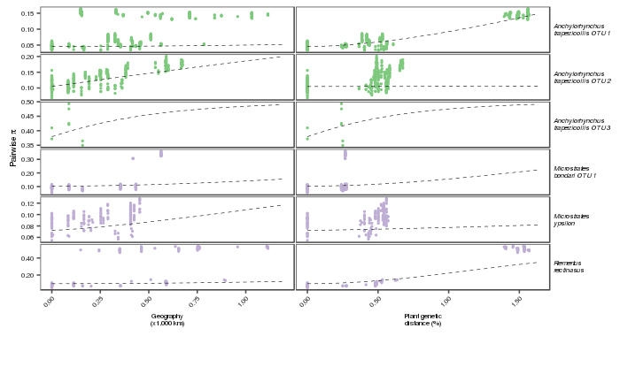

```r
clrs = RColorBrewer::brewer.pal(3,'Accent')
clrs_light = colorspace::lighten(clrs,0.5)
names(clrs) = c('Brood pollinator', 'Live tissue breeder', 'Dead tissue breeder')
var_labels = c('clim_dist' = 'Precipitation\n(mm)',
                             'geo_dist' = 'Geography\n(x1,000 km)',
                             'plant_dist' = 'Plant genetic\ndistance (%)')
ppi1 = ppi %>%
  filter(interaction %in% c('Brood pollinator', 'Live tissue breeder'))  %>%
  mutate(species = fct_drop(species)) %>%
  mutate(distance = ifelse(variable == 'geo_dist', distance/1000, distance),
         distance = ifelse(variable == 'plant_dist', distance*100, distance))
curves1 = curves_df %>%
  filter(species %in% unique(ppi1$species)) %>%
  mutate(distance = ifelse(variable == 'geo_dist', distance/1000, distance),
         distance = ifelse(variable == 'plant_dist', distance*100, distance))
p1 = ggplot(ppi1) +
  geom_point(aes(x=distance, y=pi, color=interaction),size=0.5) +
  geom_line(data = curves1,
            aes(x=distance,y=pi),
            size=0.2,
            linetype='dashed') +
  scale_color_manual(values = clrs,
                     name = 'Interaction',
                     drop = FALSE,
                     guide = 'none') +
                     #guide = guide_legend(keywidth = unit(0.1,"line"))) +
  scale_y_continuous(breaks = scales::pretty_breaks(n = 3),
                     labels = function(x) sprintf("%.2f", x)) +
  scale_x_continuous(labels = function(x) sprintf("%.2f", x)) +
  facet_grid(species~variable,
             margins=F,
             scales = 'free',
             labeller = labeller(variable=var_labels,
                                 species=label_value),
             switch='x') +
  xlab(NULL) +
  ylab(expression(Pairwise~pi)) +
  theme_few() +
  theme(strip.text.y = element_text(angle = 0,
                                    hjust = 0,
                                    face = 'italic',
                                    margin = margin(l = 0, r = 0)),
        strip.text.x = element_text(margin = margin(t=0)),
        strip.placement = "outside",
        legend.position = 'bottom',
        legend.justification = 0,
        text = element_text(size=7),
        axis.text.x = element_text(hjust = 1,angle = 45),
        axis.text.y = element_text(size=6),
        plot.margin = margin(b=1.67,t=0.2,l=0.3,r=0.3, unit = 'cm'),
        panel.spacing.y = unit(0.1, "lines"),
        panel.spacing.x = unit(0.1, "lines"))
print(p1)
```

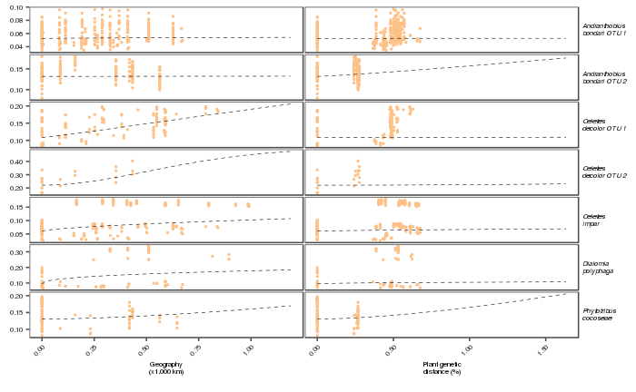

```r
ppi2 = ppi %>%
  filter(interaction == 'Dead tissue breeder') %>%
  mutate(species = fct_drop(species)) %>%
  mutate(distance = ifelse(variable == 'geo_dist', distance/1000, distance),
         distance = ifelse(variable == 'plant_dist', distance*100, distance))
curves2 = curves_df %>%
  filter(species %in% levels(ppi2$species)) %>%
  mutate(distance = ifelse(variable == 'geo_dist', distance/1000, distance),
         distance = ifelse(variable == 'plant_dist', distance*100, distance))
p2 = ggplot(ppi2) +
  geom_point(aes(x=distance, y=pi, color=interaction),size=0.5) +
  geom_line(data = curves2,
            aes(x=distance,y=pi),
            size=0.2,
            linetype='dashed') +
  scale_color_manual(values = clrs, name = 'Interaction', guide = 'none') +
  scale_y_continuous(breaks = scales::pretty_breaks(n = 3),
                     labels = function(x) sprintf("%.2f", x)) +
  scale_x_continuous(labels = function(x) sprintf("%.2f", x)) +
  facet_grid(species~variable,
             margins=F,
             scales = 'free',
             labeller = labeller(variable=var_labels,
                                 species=label_value),
             switch='x') +
  xlab(NULL) +
  ylab(NULL) +
  theme_few() +
  theme(strip.text.y = element_text(angle = 0,
                                    hjust = 0,
                                    face = 'italic',
                                    margin = margin(l = 0,r=0)),
        strip.text.x = element_text(margin = margin(t=0)),
        strip.placement = "outside",
        legend.position = 'bottom',
        text = element_text(size=7),
        axis.text.x = element_text(hjust = 1,angle = 45),
        plot.margin = margin(b=0.5,t=0.2,l=0.3,r=0.3, unit = 'cm'),
        #strip.text.x = element_blank(),
        axis.text.y = element_text(size=6),
        panel.spacing.y = unit(0.1, "lines"),
        panel.spacing.x = unit(0.1, "lines"))
print(p2)
```

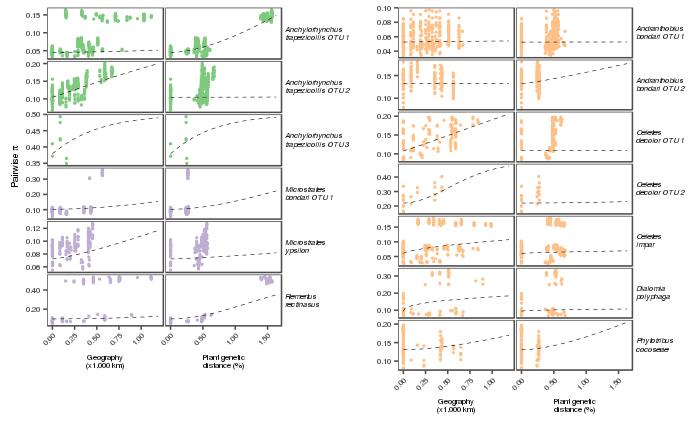

```r
p = cowplot::plot_grid(p1,
                       p2,
                       ncol = 2,
                       rel_widths = c(0.52,0.48))
print(p)
```

```r
#ggsave(filename = './figures/gen_cov_split.pdf',
#       plot = p,
#       device = 'pdf',
#       width = 18,
#       height=10,
#       units = 'cm')
```

Now as last step, let's create a legend for colors.

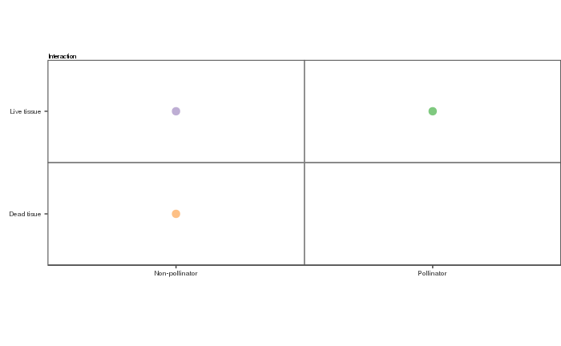

```r
key_df = data.frame(Pollinator = c('Non-pollinator', 'Pollinator'),
           Live.tissue = c('Dead tisue', 'Live tissue')) %>%
  expand.grid() %>%
  mutate(color= c("#FDC086",NA,"#BEAED4","#7FC97F"))


clr_key = ggplot(key_df) +
  theme_few() +
  geom_point(aes(x=Pollinator, y = Live.tissue, color = color), size = 3) +
  geom_tile(aes(x=Pollinator, y = Live.tissue),color='gray50', size = 0.5, fill = NA) +
  ggtitle("Interaction") +
  ylab('Larval breeding') +
  xlab('Adult pollination') +
  coord_equal(expand=F,ratio = 0.4) +
  scale_color_identity(guide = 'none') +
  theme(text = element_text(size=8),
        axis.title = element_blank(),
        plot.title = element_text(size=6,margin = margin(0,0,0,0)),
        plot.margin = margin(b=0.5,t=0,l=0.3,r=0, unit = 'cm'))
clr_key
ggsave('figures/color_key.pdf',
       clr_key + theme(plot.margin = margin(0.5,0.5,0.5,0.5,'mm')),
       device = 'pdf',
       width = 4*1.25,
       height = 3*1.25,
       units = 'cm',
       useDingbats=F)
```

```r
clr_grob = cowplot::as_grob(clr_key)
```

```
Removed 1 rows containing missing values (geom_point).
```

Now let's generate one of the figures for the main text. Italics will have to manually corrected in Adobe Illustrator later.

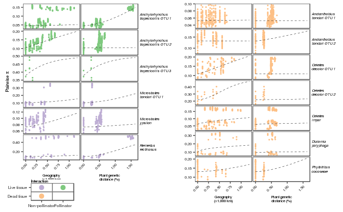

```r
p1 = p + cowplot::draw_grob(clr_grob,
                            width = 0.21,
                            height = 0.21,
                            x = 0.005,
                            #x = 0.318,
                            y = -0.04,
                            hjust = 0,
                            vjust = 0
                            )
print(p1)
ggsave(filename = './figures/gen_cov_split.pdf',
       plot = p1,
       device = 'pdf',
       width = 16,
       height= 10,
       units = 'cm',
       useDingbats = F)
```

# Testing overall effect

## Fit meta-analysis model

In addition to the plots on individual species, let's summarize, for each species, the posterior distribution of $\alpha_{dif}$, which is the difference in contribution between plant genetic distance and geography.

Let's first define a function that pulls posterior draws of $\alpha_p$ and $\alpha_g$

```r
post_diff = function(species){

  load(str_c('bedassle_results/',species,'_model.fit.Robj'))

  estimates = rstan::extract(model.fit,
                      pars=intersect(c('alphaE[1]',
                                       'alphaD'),
                                     names(model.fit))) %>%
    as_tibble %>%
    rename(aE=1, aD=2)


  return(estimates)
}
```

Now let's apply this function, calculate the difference and add information about species.

```r
pardifs = purrr::map_df(spp,post_diff,.id = 'species') %>%
  mutate(dif = aE-aD) %>%
  left_join(ecology) %>%
  mutate(interaction = factor(interaction,
                              ordered=T,
                              levels=c('Brood pollinator',
                                       'Live tissue breeder',
                                       'Dead tissue breeder'))) %>%
  mutate(species = factor(species,
                          ordered = F,
                          levels = c(
                            'Anchylorhynchus_1'  ,
                            'Anchylorhynchus_2'  ,
                            'Anchylorhynchus_3'  ,
                            'M_bondari_1'        ,
                            'M_bondari_2'        ,
                            'M_ypsilon'          ,
                            'R_rectinasus_1'     ,
                            'Andranthobius_1'    ,
                            'Andranthobius_2'    ,
                            'C_decolor_1'        ,
                            'C_decolor_2'        ,
                            'C_impar'            ,
                            'D_polyphaga'        ,
                            'P_cocoseae')
  ))
```

Now let's summarize confidence intervals to plot posterior distributions.

```r
dif_sums = pardifs %>%
  group_by(species) %>%
  summarise(ave = mean(dif),
            l50 = quantile(dif,0.25),
            u50 = quantile(dif,0.75),
            l95 = quantile(dif,0.025),
            u95 = quantile(dif,0.975),
            interaction = unique(interaction)) %>%
  mutate(species = factor(species,
                          levels = c(
                            'Anchylorhynchus_1'  ,
                            'Anchylorhynchus_2'  ,
                            'Anchylorhynchus_3'  ,
                            'M_bondari_1'        ,
                            'M_bondari_2'        ,
                            'M_ypsilon'          ,
                            'R_rectinasus_1'     ,
                            'Andranthobius_1'    ,
                            'Andranthobius_2'    ,
                            'C_decolor_1'        ,
                            'C_decolor_2'        ,
                            'C_impar'            ,
                            'D_polyphaga'        ,
                            'P_cocoseae'),
                          labels = c(
                            "italic(Anchylorhynchus~trapezicollis)~OTU~1" ,
                            "italic(Anchylorhynchus~trapezicollis)~OTU~2",
                            "italic(Anchylorhynchus~trapezicollis)~OTU~3" ,
                            "italic(Microstrates~bondari)~OTU~1"         ,
                            "italic(Microstrates~bondari)~OTU~2"         ,
                            "italic(Microstrates~ypsilon)"               ,
                            "italic(Remertus~rectinasus)"            ,
                            "italic(Andranthobius~bondari)~OTU~1"       ,
                            "italic(Andranthobius~bondari)~OTU~2"       ,
                            "italic(Celetes~decolor)~OTU~1"         ,
                            "italic(Celetes~decolor)~OTU~2"         ,
                            "italic(Celetes~impar)"                 ,
                            "italic(Dialomia~polyphaga)"             ,
                            "italic(Phytotribus~cocoseae)"
                          )),
         species = fct_reorder(species, ave),
         pos = ifelse(ave>0, -0.35, 0.35),
         just = ifelse(ave>0, 0, 1))
dif_sums
```

| species | ave | l50 | u50 | l95 | u95 | interaction | pos | just |
| --- | --- | --- | --- | --- | --- | --- | --- | --- |
| italic(Anchylorhynchus~trapezicollis)~OTU~1 | 1.418611e-01 | 0.1402248476 | 0.1434888854 | 0.1373052783 | 1.467262e-01 | Brood pollinator | -0.35 | 0 |
| italic(Anchylorhynchus~trapezicollis)~OTU~2 | -5.227200e-02 | -0.0532413114 | -0.0512580538 | -0.0553322322 | -4.916324e-02 | Brood pollinator | 0.35 | 1 |
| italic(Anchylorhynchus~trapezicollis)~OTU~3 | -4.087376e-03 | -0.0312157311 | 0.0183598942 | -0.0793216639 | 8.053481e-02 | Brood pollinator | 0.35 | 1 |
| italic(Microstrates~bondari)~OTU~1 | -1.672123e-02 | -0.0183823664 | -0.0151389766 | -0.0213482916 | -1.210792e-02 | Live tissue breeder | 0.35 | 1 |
| italic(Microstrates~ypsilon) | -3.359981e-02 | -0.0347069044 | -0.0324574202 | -0.0371560747 | -3.035611e-02 | Live tissue breeder | 0.35 | 1 |
| italic(Remertus~rectinasus) | 2.945210e-01 | 0.2903977567 | 0.2986362235 | 0.2824133002 | 3.075580e-01 | Live tissue breeder | -0.35 | 0 |
| italic(Andranthobius~bondari)~OTU~1 | -9.014627e-05 | -0.0001158682 | -0.0000501781 | -0.0002337724 | -2.160106e-05 | Dead tissue breeder | 0.35 | 1 |
| italic(Andranthobius~bondari)~OTU~2 | 1.058973e-02 | 0.0044449504 | 0.0151205652 | 0.0007899216 | 3.062499e-02 | Dead tissue breeder | -0.35 | 0 |
| italic(Celetes~decolor)~OTU~1 | -6.976850e-02 | -0.0716772455 | -0.0677066117 | -0.0753552129 | -6.417436e-02 | Dead tissue breeder | 0.35 | 1 |
| italic(Celetes~decolor)~OTU~2 | -2.015936e-01 | -0.2100150537 | -0.1943491668 | -0.2198449958 | -1.771474e-01 | Dead tissue breeder | 0.35 | 1 |

[output cut: 3 more lines]

Let's plot the distribution of $\alpha_{diff}$, ordering species by the mean estimate. We will use here the same color key as in the last plot.

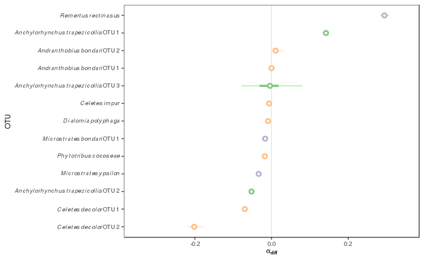

```r
p1 = ggplot(dif_sums) +
  geom_abline(intercept = 0,slope = 0, color = 'gray90') +
  geom_linerange(aes(x = species, ymin = l95, ymax = u95, color = interaction),
                 show.legend = F) +
  scale_color_manual(values = clrs_light, name = 'Interaction') +
  ggnewscale::new_scale_color()+
  geom_linerange(aes(x = species, ymin = l50, ymax = u50, color = interaction),
                 size=1.3,
                 show.legend = F) +
  geom_point(aes(x = species, y = ave, color = interaction),
             fill = 'white',
             stroke = 1.5,
             shape = 21,
             size = 1.5) +
  scale_color_manual(values = clrs, name = 'Interaction', guide = 'none') +
  scale_fill_manual(values = clrs_light, name = 'Interaction', guide = 'none') +
  #geom_errorbar(aes(x = species, ymin = ave, ymax=ave, color = interaction)) +
  #geom_text(aes(x=species,y=pos,label=species,hjust=just), parse=T, size = 3) +
  #guides(color = guide_legend(override.aes = list(size = 1.5))) +
  ylab(expression(alpha[diff])) +
  coord_flip()+
  xlab("OTU") +
  scale_x_discrete(labels = parse(text = levels(dif_sums$species))) +
  ylim(c(-0.35,0.35)) +
  theme_few() +
  theme(legend.position = c(0.99,0.01),
        legend.justification = c(1,0),
        text=element_text(size=9),
        legend.text = element_text(size=6),
        legend.key.size = unit(8, 'pt'),
        legend.title = element_text(size=7))
print(p1)
```

```r
NA
```

It does not look like there is a strong association between mode of interaction and whether plants drive diversification. Let's use a meta-analysis model to test whether being a pollinator decreases this difference and being an antagonist increases it. For each species, let's record the average $\alpha_{diff}$, the standard deviation, and whether they are pollinators or antagonists.

```r
stan_df = pardifs %>%
  group_by(species) %>%
  summarise(y=mean(dif), sigma=sd(dif)) %>%
  left_join(ecology) %>%
  mutate(pollinator = str_detect(interaction, 'pollinator'),
         antagonist = !str_detect(interaction, 'Dead')) %>%
  select(-interaction) %>%
  arrange(y)
stan_df
```

| species | y | sigma | pollinator | antagonist |
| --- | --- | --- | --- | --- |
| C_decolor_2 | -2.015936e-01 | 1.133899e-02 | FALSE | FALSE |
| C_decolor_1 | -6.976850e-02 | 2.883937e-03 | FALSE | FALSE |
| Anchylorhynchus_2 | -5.227200e-02 | 1.539011e-03 | TRUE | TRUE |
| M_ypsilon | -3.359981e-02 | 1.740548e-03 | FALSE | TRUE |
| P_cocoseae | -1.756420e-02 | 1.575828e-03 | FALSE | FALSE |
| M_bondari_1 | -1.672123e-02 | 2.391672e-03 | FALSE | TRUE |
| D_polyphaga | -9.159361e-03 | 2.769643e-03 | FALSE | FALSE |
| C_impar | -6.380943e-03 | 3.909683e-04 | FALSE | FALSE |
| Anchylorhynchus_3 | -4.087376e-03 | 4.002680e-02 | TRUE | TRUE |
| Andranthobius_1 | -9.014627e-05 | 5.818045e-05 | FALSE | FALSE |

[output cut: 3 more lines]

Let's now run the model.

```r
stan_input = as.list(stan_df)
stan_input$N = nrow(stan_df)
#stan_input$y = (stan_input$y- mean(stan_input$y))/sd(stan_input$y)
str(stan_input)
```

```
List of 6
 $ species   : Factor w/ 14 levels "Anchylorhynchus_1",..: 11 10 2 6 14 4 13 12 3 8 ...
 $ y         : num [1:13] -0.2016 -0.0698 -0.0523 -0.0336 -0.0176 ...
 $ sigma     : num [1:13] 0.01134 0.00288 0.00154 0.00174 0.00158 ...
 $ pollinator: logi [1:13] FALSE FALSE TRUE FALSE FALSE FALSE ...
 $ antagonist: logi [1:13] FALSE FALSE TRUE TRUE FALSE TRUE ...
 $ N         : int 13
```

```r
fit = sampling(meta_model,
               seed = 1986317581,
               data = stan_input,
               iter = 2000,
               chains = 4,
               cores = 1,
               refresh = 2000,
               control = list(adapt_delta = 0.98, max_treedepth = 17))
```

Let's now save the fitted model.

```r
saveRDS(fit,file = 'stan_hier.rds')
```

## Model check

```r
#shinystan::launch_shinystan(fit)
```

To check if the model is doing a good job in fitting observations, let's plot $\alpha_{diff}$ that was used as input data agains posterior predictive draws:

```r
pps = rstan::extract(fit, pars='yrep',permuted=TRUE) %>%
  (function(x)x[[1]]) %>%
  t %>%
  as.data.frame %>%
  mutate(species = stan_df$species) %>%
  gather(key='iteration',value='yrep',-species) %>%
  mutate(species = factor(species,
                          ordered = T,
                          levels = c(
                            'Anchylorhynchus_1'  ,
                            'Anchylorhynchus_2'  ,
                            'Anchylorhynchus_3'  ,
                            'M_bondari_1'        ,
                            'M_bondari_2'        ,
                            'M_ypsilon'          ,
                            'R_rectinasus_1'     ,
                            'Andranthobius_1'    ,
                            'Andranthobius_2'    ,
                            'C_decolor_1'        ,
                            'C_decolor_2'        ,
                            'C_impar'            ,
                            'D_polyphaga'        ,
                            'P_cocoseae'),
                          labels = c(
                            "italic(Anchylorhynchus~trapezicollis)~OTU~1" ,
                            "italic(Anchylorhynchus~trapezicollis)~OTU~2",
                            "italic(Anchylorhynchus~trapezicollis)~OTU~3" ,
                            "italic(Microstrates~bondari)~OTU~1"         ,
                            "italic(Microstrates~bondari)~OTU~2"         ,
                            "italic(Microstrates~ypsilon)"               ,
                            "italic(Remertus~rectinasus)"            ,
                            "italic(Andranthobius~bondari)~OTU~1"       ,
                            "italic(Andranthobius~bondari)~OTU~2"       ,
                            "italic(Celetes~decolor)~OTU~1"         ,
                            "italic(Celetes~decolor)~OTU~2"         ,
                            "italic(Celetes~impar)"                 ,
                            "italic(Dialomia~polyphaga)"             ,
                            "italic(Phytotribus~cocoseae)"
                          ))) %>%
  group_by(species) %>%
  slice(1:500) %>%
  ungroup %>%
  mutate(species = fct_reorder(species, yrep))
pps
```

| species | iteration | yrep |
| --- | --- | --- |
| italic(Anchylorhynchus~trapezicollis)~OTU~1 | V1 | 0.13780585 |
| italic(Anchylorhynchus~trapezicollis)~OTU~1 | V2 | 0.14495492 |
| italic(Anchylorhynchus~trapezicollis)~OTU~1 | V3 | 0.14419808 |
| italic(Anchylorhynchus~trapezicollis)~OTU~1 | V4 | 0.14111793 |
| italic(Anchylorhynchus~trapezicollis)~OTU~1 | V5 | 0.14310704 |
| italic(Anchylorhynchus~trapezicollis)~OTU~1 | V6 | 0.14570952 |
| italic(Anchylorhynchus~trapezicollis)~OTU~1 | V7 | 0.14993147 |
| italic(Anchylorhynchus~trapezicollis)~OTU~1 | V8 | 0.14433373 |
| italic(Anchylorhynchus~trapezicollis)~OTU~1 | V9 | 0.14689278 |
| italic(Anchylorhynchus~trapezicollis)~OTU~1 | V10 | 0.13869722 |

[output cut: 990 more lines]

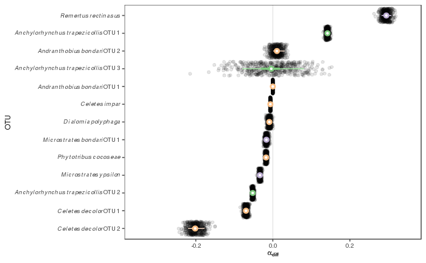

```r
p = ggplot(dif_sums) +
  geom_abline(intercept = 0,slope = 0, color = 'gray90') +
  geom_jitter(aes(x=species,y=yrep),data=pps,alpha=0.1) +
  geom_linerange(aes(x = species, ymin = l95, ymax = u95, color = interaction),
                 show.legend = F) +
  scale_color_manual(values = clrs_light, name = 'Interaction') +
  ggnewscale::new_scale_color()+
  geom_linerange(aes(x = species, ymin = l50, ymax = u50, color = interaction),
                 size=1.3,
                 show.legend = F) +
  geom_point(aes(x = species, y = ave, color = interaction),
             fill = 'white',
             stroke = 1.5,
             shape = 21,
             size = 1.5) +
  scale_color_manual(values = clrs, name = 'Interaction', guide = 'none') +
  scale_fill_manual(values = clrs_light, name = 'Interaction', guide = 'none') +
  #geom_errorbar(aes(x = species, ymin = ave, ymax=ave, color = interaction)) +
  #geom_text(aes(x=species,y=pos,label=species,hjust=just), parse=T, size = 3) +
  #guides(color = guide_legend(override.aes = list(size = 1.5))) +
  ylab(expression(alpha[diff])) +
  coord_flip()+
  xlab("OTU") +
  scale_x_discrete(labels = parse(text = levels(pps$species))) +
  ylim(c(-0.35,0.35)) +
  theme_few() +
  theme(legend.position = c(0.99,0.01),
        legend.justification = c(1,0),
        text=element_text(size=9),
        #axis.text.y = element_text(face = 'italic',hjust=1),
        legend.text = element_text(size=6),
        legend.key.size = unit(8, 'pt'),
        legend.title = element_text(size=7))


print(p)
ggsave('figures/posterior_predictions_meta.pdf',
       p,
       device='pdf',
       width=168,
       height=168*3/4,
       units = 'mm',
       useDingbats=F)
```

It seems we are inferring with a little more variance than the original data, but the model is capturing the correct posterior estimates.

Let's now plot the posterior estimates.

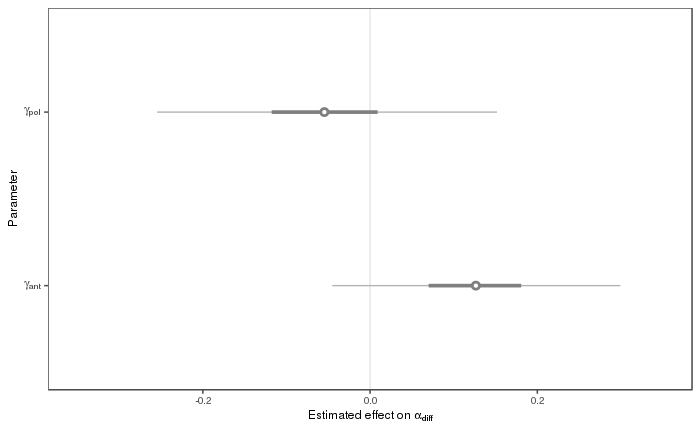

```r
p2 = summary(fit, pars=c('ant','pol'))$summary %>%
  as.data.frame() %>%
  rownames_to_column('parameter') %>%
  #mutate(parameter=c('expression(gamma[a])','expression(gamma[p])')) %>%
  ggplot() +
  geom_abline(intercept = 0,slope = 0, color = 'gray90') +
  geom_linerange(aes(x = parameter, ymin = `2.5%`, ymax = `97.5%`),
                 color='gray70',
                 show.legend = F) +
  geom_linerange(aes(x = parameter, ymin = `25%`, ymax = `75%`),
                 color='gray50',
                 size = 1.3,
                 show.legend = F) +
  geom_point(aes(x = parameter, y = mean),
             color='gray50',
             fill = 'white',
             stroke = 1.5,
             shape = 21,
             size = 1.5) +
  #geom_errorbar(aes(x = parameter, ymin = mean, ymax=mean),
  #              color='gray50') +
  scale_x_discrete(labels=parse(text=c('gamma[ant]','gamma[pol]'))) +
  ylab(expression(Estimated~effect~on~alpha[diff])) +
  xlab("Parameter") +
  coord_flip() +
  ylim(c(-0.35,0.35)) +
  theme_few()+
  theme(legend.position='bottom',
        text = element_text(size=9),
        axis.text.y = element_text(size=9))
print(p2)
```

```r
NA
```

Pollination does not seem to have a significant effect, and antagonism has a small effect but nonsignificant if we consider the whole posterior interval. Maybe with this sample size we do not have enough power to detect differences? To test, let's relabel our input data and consider that the top 3 species are antagonists, the next 3 are brood pollinators and remaining seven are commensals. We will fit the model and plot posterior estimates.

```r
stan_fake = stan_input
stan_fake$pollinator = c(rep(FALSE,7),rep(TRUE,3),rep(FALSE,3))
stan_fake$antagonist = c(rep(FALSE,7),rep(TRUE,6))
fake.fit = sampling(meta_model,
               seed = 9761,
               data = stan_fake,
               iter = 2000,
               chains = 4,
               cores = 1,
               refresh = 2000,
               control = list(adapt_delta = 0.98, max_treedepth = 17))
```

```
There were 3 transitions after warmup that exceeded the maximum treedepth. Increase max_treedepth above 17. See
http://mc-stan.org/misc/warnings.html#maximum-treedepth-exceededExamine the pairs() plot to diagnose sampling problems
```

```r
saveRDS(fit,file = 'stan_hier_fake.rds')
```

And check the run with shinystan. This is commented out in the notebook since results can only be seen when running interactively.

```r
#shinystan::launch_shinystan(fake.fit)
```

It seems that with the relabelled data we have power to distinguish coefficients from 0:

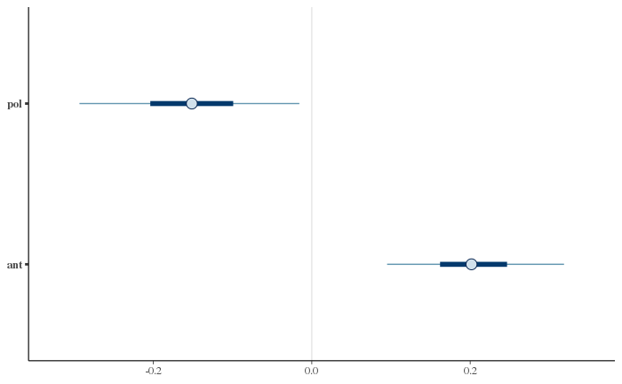

```r
bayesplot::mcmc_intervals(as.array(fake.fit), pars = c('pol','ant'))
```

# Meta-analysis figures

Let's now prepare a final figure for the meta-analysis results, using cowplot. We will combine it with the color key manually later by using Adobe Illustrator.

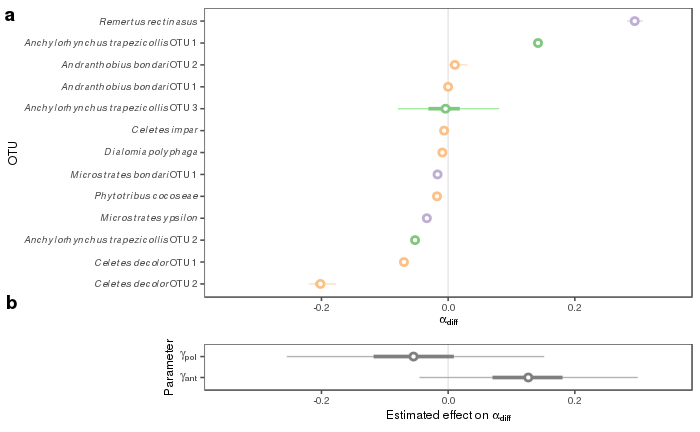

```r
p = cowplot::plot_grid(p1,
                       p2,
                   ncol=1,
                   rel_heights = c(0.7,0.2),
                   align='v',
                   axis=c('lr'),
                   labels = 'auto',
                   label_y = c(1,1.5))
print(p)
ggsave('figures/meta_results.pdf',
       p,
       device='pdf',
       width=168/2*3,
       height=120,
       units = 'mm',
       useDingbats=F)
```

Let's also export a figure for supplementary material with the relabelled data to test the power of the test.

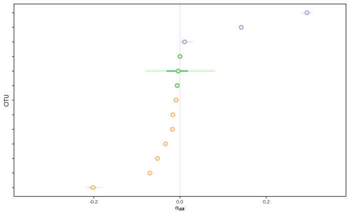

```r
fake_dif_sums = dif_sums %>% arrange(ave)
fake_dif_sums$interaction = factor(c(rep("Dead tissue breeder", 7),
                              rep("Brood pollinator", 3),
                              rep("Live tissue breeder", 3)),
                              levels = c("Brood pollinator",
                                         "Live tissue breeder",
                                         "Dead tissue breeder"))
p1 = ggplot(fake_dif_sums) +
  geom_abline(intercept = 0,slope = 0, color = 'gray90') +
  geom_linerange(aes(x = species, ymin = l95, ymax = u95, color = interaction),
                 show.legend = F) +
  scale_color_manual(values = clrs_light, name = 'Interaction') +
  ggnewscale::new_scale_color()+
  geom_linerange(aes(x = species, ymin = l50, ymax = u50, color = interaction),
                 size=1.3,
                 show.legend = F) +
  geom_point(aes(x = species, y = ave, color = interaction),
             fill = 'white',
             stroke = 1.5,
             shape = 21,
             size = 1.5) +
  scale_color_manual(values = clrs, name = 'Interaction', guide = 'none') +
  scale_fill_manual(values = clrs_light, name = 'Interaction', guide = 'none') +
  #geom_errorbar(aes(x = species, ymin = ave, ymax=ave, color = interaction)) +
  #geom_text(aes(x=species,y=pos,label=species,hjust=just), parse=T, size = 3) +
  #guides(color = guide_legend(override.aes = list(size = 1.5))) +
  ylab(expression(alpha[diff])) +
  coord_flip()+
  xlab("OTU") +
  ylim(c(-0.35,0.35)) +
  theme_few() +
  theme(axis.text.y = element_blank(),
        legend.position = c(0.99,0.01),
        legend.justification = c(1,0),
        text=element_text(size=9),
        legend.text = element_text(size=6),
        legend.key.size = unit(8, 'pt'),
        legend.title = element_text(size=7))
print(p1)
```

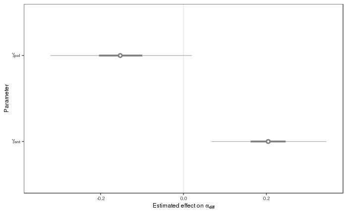

```r
p2 = summary(fake.fit, pars=c('ant','pol'))$summary %>%
  as.data.frame() %>%
  rownames_to_column('parameter') %>%
  #mutate(parameter=c('expression(gamma[a])','expression(gamma[p])')) %>%
  ggplot() +
  geom_abline(intercept = 0,slope = 0, color = 'gray90') +
  geom_linerange(aes(x = parameter, ymin = `2.5%`, ymax = `97.5%`),
                 color='gray70',
                 show.legend = F) +
  geom_linerange(aes(x = parameter, ymin = `25%`, ymax = `75%`),
                 color='gray50',
                 size = 1.3,
                 show.legend = F) +
  geom_point(aes(x = parameter, y = mean),
             color='gray50',
             fill = 'white',
             stroke = 1.5,
             shape = 21,
             size = 1.5) +
  #geom_errorbar(aes(x = parameter, ymin = mean, ymax=mean),
  #              color='gray50') +
  scale_x_discrete(labels=parse(text=c('gamma[ant]','gamma[pol]'))) +
  ylab(expression(Estimated~effect~on~alpha[diff])) +
  xlab("Parameter") +
  coord_flip() +
  ylim(c(-0.35,0.35)) +
  theme_few()+
  theme(legend.position='bottom',
        text = element_text(size=9),
        axis.text.y = element_text(size=9))
print(p2)
```

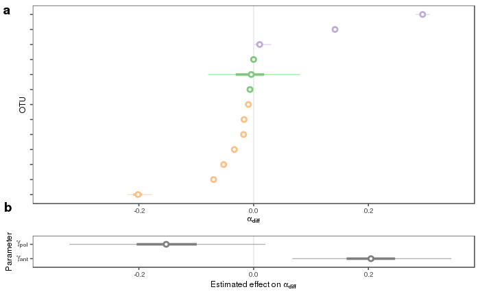

```r
p = cowplot::plot_grid(p1,p2,
                   ncol=1,
                   rel_heights = c(0.7,0.2),
                   align='v',
                   axis=c('lr'),
                   labels = 'auto',
                   label_y = c(1,1.5))
print(p)
ggsave('figures/meta_supplement.pdf',
       p,
       device='pdf',
       width=168,
       height=100,
       units = 'mm',
       useDingbats=F)
```